# Class 10: Disney/Pixar: Corporate Strategy

MG106 Strategic Management

José Ignacio González Rojas

j.i.gonzalez-rojas@lse.ac.uk

London School of Economics and Political Science

July 7, 2026

## Disney/Pixar tests whether ownership protects or damages value

### Contract, partnership, or acquisition?

Robert Iger needs to decide whether Disney should renegotiate with Pixar, form a deeper exclusive relationship, or acquire Pixar outright.

The case is about firm boundaries: what should Disney coordinate by contract, and what should it own?

## Four questions structure today’s corporate-strategy decision

### Value creation, ownership, integration risk, and organisation design

#### Four questions for the case discussion

1. What value could Disney and Pixar create together?
2. Can that value be captured through a renewed contract?
3. If Disney acquires Pixar, what could be damaged?
4. How should the combined organisation be designed?

Do not jump from “synergy exists” to “therefore acquire.”

# Firm boundaries decide what Disney should coordinate by contract or ownership

## Corporate strategy decides what sits inside the firm

### Business strategy versus corporate strategy

#### Business strategy

- How does one business create and capture value?
- Which customers, activities, resources, and rivals matter?
- Example: how Pixar makes successful animated films

#### Corporate strategy

- Which businesses or activities should share ownership?
- When is a contract enough?
- Example: whether Disney needs to own Pixar

Corporate ownership must create value net of coordination and integration costs.

## The decision set is wider than buy or walk away

### Compare alternatives before recommending acquisition

1. **Renew distribution contract.** Preserves the relationship with limited disruption; rights, sequels, and bargaining conflict may return.
2. **Exclusive long-term partnership.** Improves coordination without full ownership; the contract remains incomplete.
3. **Acquire Pixar.** Coordinates films, characters, rights, distribution, and franchises; risks overpayment or creative-process damage.
4. **Build Disney CG internally.** Avoids the acquisition premium; capability development may be slow.
5. **Hire talent selectively.** Acquires individuals rather than the whole firm; the capability may not transfer without the system.

## Disney’s downstream leverage could make Pixar characters more valuable

### Evidence → mechanism → implication

#### Case evidence

- Distribution and release capabilities
- Marketing and brand reach
- Consumer products, parks, and franchise extensions
- Experience turning characters into long-lived assets

#### Strategic implication

Disney may make each successful animated character more valuable by connecting films to distribution, marketing, sequels, consumer products, and parks.

But that does not automatically prove Disney must own Pixar.

## Pixar’s asset is an accumulated creative system, not only CGI technology

### The target is not only technology

#### Case evidence

- CGI capability and proprietary tools
- Repeated hit-making record
- Creative leadership and story discipline
- Production routines developed over time
- Culture of open feedback and “plussing”

#### Strategic implication

Pixar’s value depends on a system of people, routines, technology, and culture. Buying the legal entity is not the same as preserving that accumulated creative system.

## Film-performance exhibits make Pixar’s capability visible

### The target was a repeatable creative system, not one lucky film

#### Disney animation evidence

- Disney had historically created powerful animated assets
- Recent output before 2005 was more uneven
- Downstream assets remained valuable if compelling characters existed

#### Pixar evidence

- Every released Pixar feature had been a major CG success
- Average box office performance exceeded Disney’s recent animated-film average
- The pattern suggests routines, culture, and leadership, not a one-off technology asset

Performance supports value creation, not yet ownership.

# Two tests separate value creation from ownership justification

## The Better-Off Test asks whether together is better than apart

### Value creation before ownership

Corporate strategy passes the Better-Off Test only if the combination creates more value than the parties could create separately or through looser arrangements.

#### Possible value sources

- Better release and marketing coordination
- Stronger franchise development
- More reliable access to creative output and characters
- Better coordination around sequels and rights

#### Required caution

- Some value may already be available through contract
- Synergies may be smaller than the acquisition premium
- Integration may reduce the capability being acquired
- Pixar may have credible outside options

## Complementary assets create a value-creation hypothesis, not yet an ownership case

### Disney and Pixar have different strengths

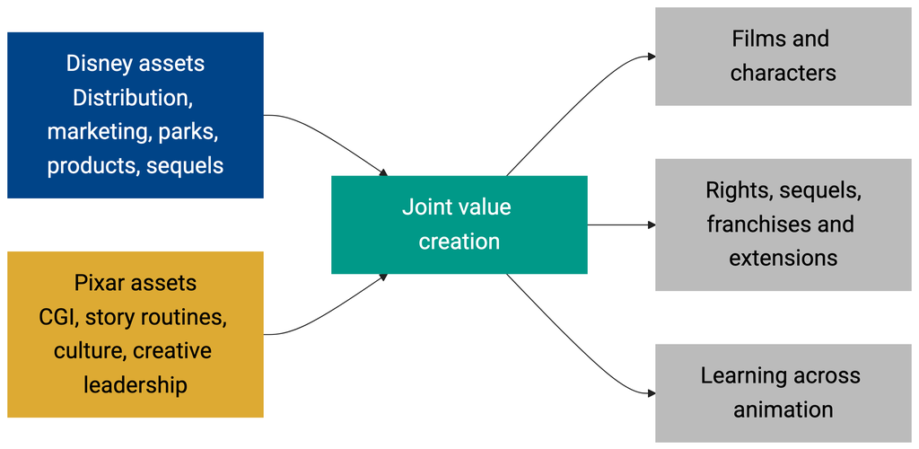

The map shows a value-creation hypothesis, not yet an ownership argument.

## The Ownership Test asks whether contracts leave value unrealised

### Ownership is justified only if market arrangements leave value unrealised

#### Reasons a contract may be enough

- Disney can distribute films for a fee
- Pixar can retain creative autonomy
- Each side can keep incentives clear
- Less risk of cultural disruption

#### Reasons ownership may matter

- Future rights and sequels are hard to specify
- Relationship-specific investment may be underprovided
- Bargaining conflict may block long-run value
- Disney may need secure access to Pixar characters and capabilities

## Revenue-breakdown and valuation exhibits shift the question to value capture

### Creating value and capturing value are different tests

#### Contract economics

- Disney earned distribution fees and downstream income
- Pixar captured a large share of production economics under the co-production logic
- Rights, sequels, and franchise extensions were recurring bargaining issues

#### Acquisition economics

- Ownership could reduce bargaining conflict and improve coordination
- The acquisition premium could transfer much of the expected synergy to Pixar shareholders
- Integration risk could destroy the capability Disney was buying

Who captures value after price and integration risk?

## Corporate Strategy Is Also a Price Question

**Do not stop at “Pixar is valuable.”**

If Disney pays the full value of all expected synergies to Pixar shareholders, Disney may create value operationally but capture little or none of it for its own shareholders.

A recommendation needs a view on both:

1. value created by combining assets; and
2. value captured after acquisition price, integration costs, and risk.

# Organisation design determines whether the acquired capability survives

## Acquisition can damage the asset Disney is trying to buy

### Integration risk is central to the case

#### Creative culture loss

Pixar’s routines are part of the asset, so preserve autonomy in creative decisions.

#### Talent exit

Capability may reside in teams, not contracts, so retain creative leadership and incentives.

#### Bureaucratic delay

Corporate processes can slow creative iteration, so keep fast approval and feedback routines.

#### Misallocated resources

Internal capital markets can blur accountability, so define where Disney coordinates and where Pixar decides.

## Integration design requires selective connection, not full absorption

### Own the relationship without absorbing everything

#### Integrate where Disney adds value

- Distribution timing
- Rights and sequel coordination
- Franchise planning
- Consumer products and parks
- Capital allocation across the animation portfolio

#### Protect where Pixar creates value

- Story development routines
- Creative leadership and brain-trust style feedback
- Production culture
- Technical problem solving
- Talent incentives and identity

The organisational design is part of the strategy, not an implementation afterthought.

## A recommendation must defend the ownership and organisation assumptions

### Choose one option and defend the assumptions

#### Your options

1. Renew the contract
2. Create a deeper exclusive partnership
3. Acquire Pixar
4. Build Disney CGI or hire talent another way

#### Your answer must state

- what value is created;
- why ownership is or is not required;
- what risks could destroy value;
- how Disney should organise the relationship.

## Strong corporate-strategy answers use the tests in sequence

### Value, ownership, price, organisation, recommendation

1. **Value:** what could the combination create?
2. **Ownership:** why can or cannot a contract capture that value?
3. **Price:** who captures the value after payment and risk?
4. **Organisation:** what design protects the critical capability?
5. **Recommendation:** what should the firm do, and under which assumptions?

A strong answer explains why ownership changes incentives, coordination, and capability preservation.

## Disney/Pixar shows that ownership is a design problem, not just a transaction

### Corporate strategy is about boundaries and organisation

Disney/Pixar is not only an acquisition case.

It is a test of whether common ownership can create and preserve value better than contracts.

The hard part is designing ownership so that the acquired capability survives.